# lab6

Author

Ran Zhu

## Setup

```r
knitr::opts_chunk$set(
  eval = TRUE,
  include = TRUE,
  warning = FALSE,
  message = FALSE
)

library(readr)
library(dplyr)
library(ggplot2)
library(tidytext)
library(forcats)
library(tidyr)
```

```r
mt_samples <- read_csv(
  "https://raw.githubusercontent.com/USCbiostats/data-science-data/master/00_mtsamples/mtsamples.csv"
)

mt_samples <- mt_samples |>
  select(description, medical_specialty, transcription)

head(mt_samples)
```

```
# A tibble: 6 × 3
  description                                    medical_specialty transcription
  <chr>                                          <chr>             <chr>
1 A 23-year-old white female presents with comp… Allergy / Immuno… "SUBJECTIVE:…
2 Consult for laparoscopic gastric bypass.       Bariatrics        "PAST MEDICA…
3 Consult for laparoscopic gastric bypass.       Bariatrics        "HISTORY OF …
4 2-D M-Mode. Doppler.                           Cardiovascular /… "2-D M-MODE:…
5 2-D Echocardiogram                             Cardiovascular /… "1.  The lef…
6 Morbid obesity.  Laparoscopic antecolic anteg… Bariatrics        "PREOPERATIV…
```

## Q1: How many different categories? Are these categories related or overlapping? Are they evenly distributed?

```r
mt_samples %>%
  count(medical_specialty, sort = TRUE)
```

```
# A tibble: 40 × 2
   medical_specialty                 n
   <chr>                         <int>
 1 Surgery                        1103
 2 Consult - History and Phy.      516
 3 Cardiovascular / Pulmonary      372
 4 Orthopedic                      355
 5 Radiology                       273
 6 General Medicine                259
 7 Gastroenterology                230
 8 Neurology                       223
 9 SOAP / Chart / Progress Notes   166
10 Obstetrics / Gynecology         160
# ℹ 30 more rows
```

## Q2: Most Frequent Words in Medical Transcriptions

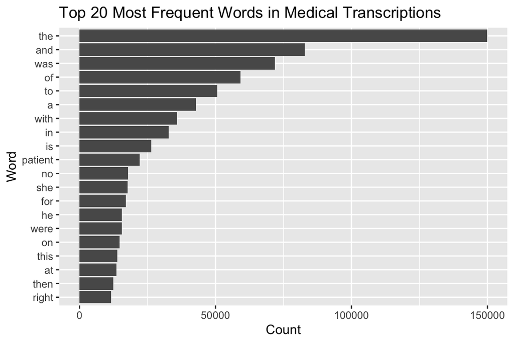

```r
mt_samples |>
  unnest_tokens(word, transcription) |>
  count(word) |>
  top_n(20, n) |>
  ggplot(aes(n, fct_reorder(word, n))) +
  geom_col() +
  labs(
    title = "Top 20 Most Frequent Words in Medical Transcriptions",
    x = "Count",
    y = "Word"
  )
```

The most frequent word is “the,” which appears about 150,000 times, followed by words such as “and,” “was,” “of,” and “to.” This makes sense because these are commonly used English words, but they do not tell us much about the medical content. “Patient” and “right” are among the few words that provide more useful information. Overall, the main insight is that the word counts are dominated by common stop words, making it difficult to identify what the reports are mainly about. Removing these stop words may reveal more meaningful medical terms.

## Q3: Most Frequent Words After Removing Stop Words

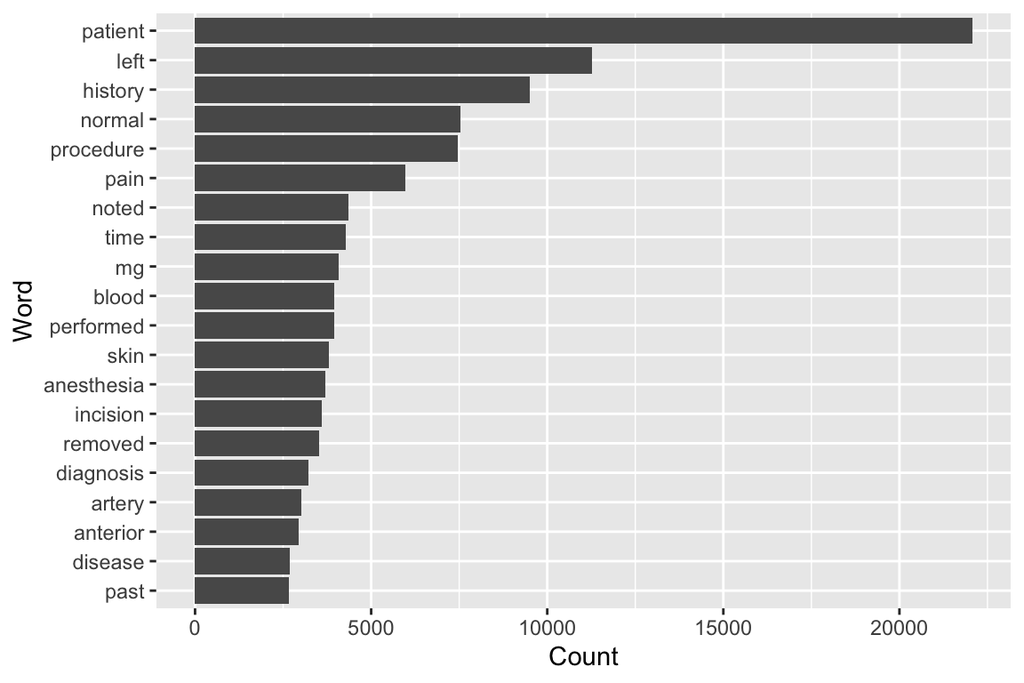

```r
mt_samples |>
  unnest_tokens(word, transcription) |>
  anti_join(stop_words, by = c("word")) |>
  filter(!grepl("^[0-9]+$", word)) |>
  count(word) |>
  top_n(20, n) |>
  ggplot(aes(n, fct_reorder(word, n))) +
  geom_col() +
  labs(
    x = "Count",
    y = "Word"
  )
```

After removing stop words and numbers, the most frequent word is “patient,” followed by “left,” “history,” “normal,” and “procedure.” The remaining words are more related to medical reports, including symptoms such as “pain,” anatomical terms such as “artery” and “skin,” and procedure-related words such as “anesthesia,” “incision,” and “performed.” This gives us a better idea of the text because it shows that the reports mainly describe patients, medical histories, diagnoses, and procedures.

## Q4: Most Frequent Bi-grams and Tri-grams

### Bi-grams

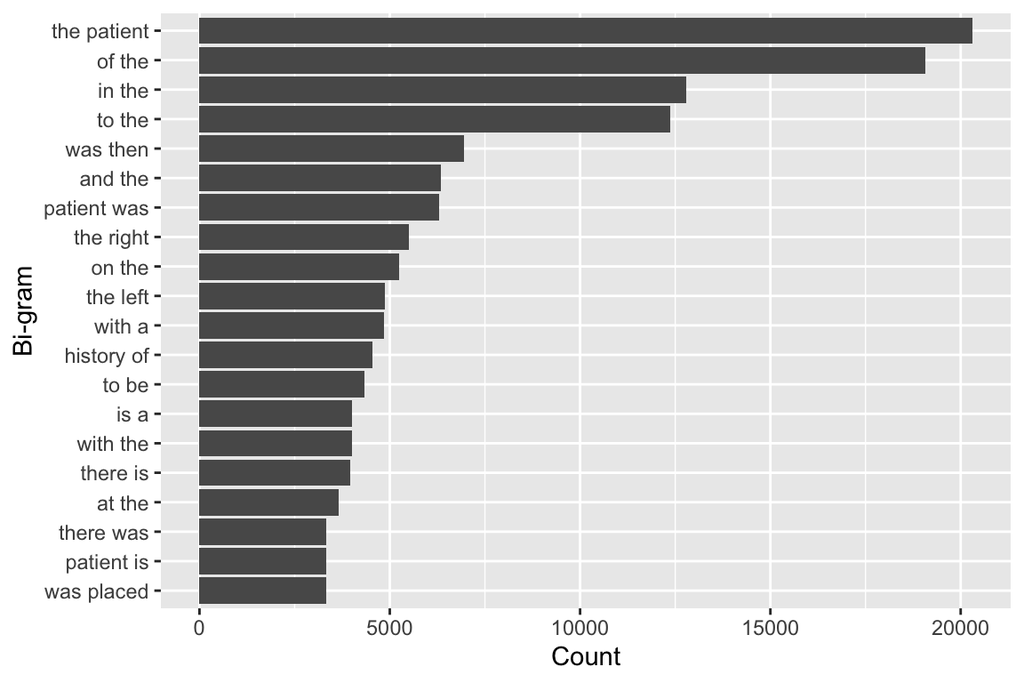

```r
mt_samples |>
  unnest_ngrams(ngram, transcription, n = 2) |>
  count(ngram) |>
  top_n(20, n) |>
  ggplot(aes(n, fct_reorder(ngram, n))) +
  geom_col() +
  labs(
    x = "Count",
    y = "Bi-gram"
  )
```

### Tri-grams

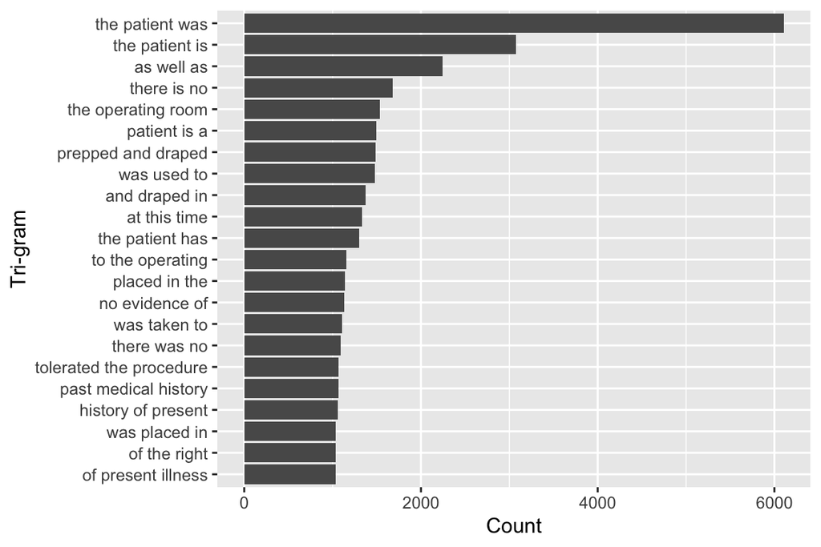

```r
mt_samples |>
  unnest_ngrams(ngram, transcription, n = 3) |>
  count(ngram) |>
  top_n(20, n) |>
  ggplot(aes(n, fct_reorder(ngram, n))) +
  geom_col() +
  labs(
    x = "Count",
    y = "Tri-gram"
  )
```

For the bigrams, “the patient” appears most often, followed by phrases like “of the,” “in the,” and “to the.” The trigrams are longer and show more complete ideas, such as “the patient was,” “the operating room,” “prepped and draped,” “tolerated the procedure,” and “past medical history.” The trigram counts are lower than the bigram counts because the same three-word sequence is less likely to be repeated than a two-word sequence. Overall, the trigrams are more helpful for understanding the common language used to describe patient histories and medical procedures.

## Q5: Words Before and After “Patient” (chose from Q4)

### before “patient”

```r
mt_samples |>
  unnest_ngrams(ngram, transcription, n = 2) |>
  separate(ngram, into = c("word1", "word2"), sep = " ") |>
  select(word1, word2) |>
  filter(word2 == "patient") |>
  count(word1, sort = TRUE)
```

```
# A tibble: 269 × 2
   word1         n
   <chr>     <int>
 1 the       20307
 2 this        470
 3 history     101
 4 a            67
 5 and          47
 6 procedure    32
 7 female       26
 8 with         25
 9 use          24
10 old          23
# ℹ 259 more rows
```

### After “patient”

```r
mt_samples |>
  unnest_ngrams(ngram, transcription, n = 2) |>
  separate(ngram, into = c("word1", "word2"), sep = " ") |>
  select(word1, word2) |>
  filter(word1 == "patient") |>
  count(word2, sort = TRUE)
```

```
# A tibble: 588 × 2
   word2         n
   <chr>     <int>
 1 was        6293
 2 is         3332
 3 has        1417
 4 tolerated   994
 5 had         888
 6 will        616
 7 denies      552
 8 and         377
 9 states      363
10 does        334
# ℹ 578 more rows
```

The most common word before “patient” is “the,” forming the phrase “the patient” 20,307 times. “This” and “history” also appear before “patient,” but much less often. For words after “patient,” the most common are “was” (6,293), “is” (3,332), and “has” (1,417). This makes sense because phrases such as “the patient was,” “the patient is,” and “the patient has” are commonly used in medical reports.

## Q6: Most-Used Words by Medical Specialty

```r
mt_samples |>
  unnest_tokens(word, transcription) |>
  anti_join(stop_words, by = c("word")) |>
  filter(!grepl("^[0-9]+$", word)) |>
  group_by(medical_specialty) |>
  count(word) |>
  top_n(5, n) |>
  arrange(medical_specialty, desc(n))
```

```
# A tibble: 210 × 3
# Groups:   medical_specialty [40]
   medical_specialty    word          n
   <chr>                <chr>     <int>
 1 Allergy / Immunology history      38
 2 Allergy / Immunology noted        23
 3 Allergy / Immunology patient      22
 4 Allergy / Immunology allergies    21
 5 Allergy / Immunology nasal        13
 6 Allergy / Immunology past         13
 7 Autopsy              left         83
 8 Autopsy              inch         59
 9 Autopsy              neck         55
10 Autopsy              anterior     47
# ℹ 200 more rows
```

For Allergy / Immunology, the most-used word is “history,” which appears 38 times, followed by “noted” 23 times, “patient” 22 times, and “allergies” 21 times. Both “nasal” and “past” appear 13 times, so they are tied for fifth place.

## Q7: extra

### See if certain words are used more in some specialties than others.

### - Use of “Pain” across medical specialties

```r
pain_by_specialty <- mt_samples |>
  unnest_tokens(word, transcription) |>
  group_by(medical_specialty) |>
  summarize(
    total_words = n(),
    pain_count = sum(word == "pain"),
    pain_per_1000 = pain_count / total_words * 1000
  ) |>
  arrange(desc(pain_per_1000))

pain_by_specialty
```

```
# A tibble: 40 × 4
   medical_specialty             total_words pain_count pain_per_1000
   <chr>                               <int>      <int>         <dbl>
 1 Chiropractic                        13446        187         13.9
 2 Physical Medicine - Rehab            9715         95          9.78
 3 IME-QME-Work Comp etc.              17889        152          8.50
 4 Letters                             11895         80          6.73
 5 Emergency Room Reports              43598        273          6.26
 6 Hospice - Palliative Care            4171         19          4.56
 7 Rheumatology                         5059         23          4.55
 8 General Medicine                   126790        567          4.47
 9 Discharge Summary                   45362        180          3.97
10 SOAP / Chart / Progress Notes       62253        239          3.84
# ℹ 30 more rows
```

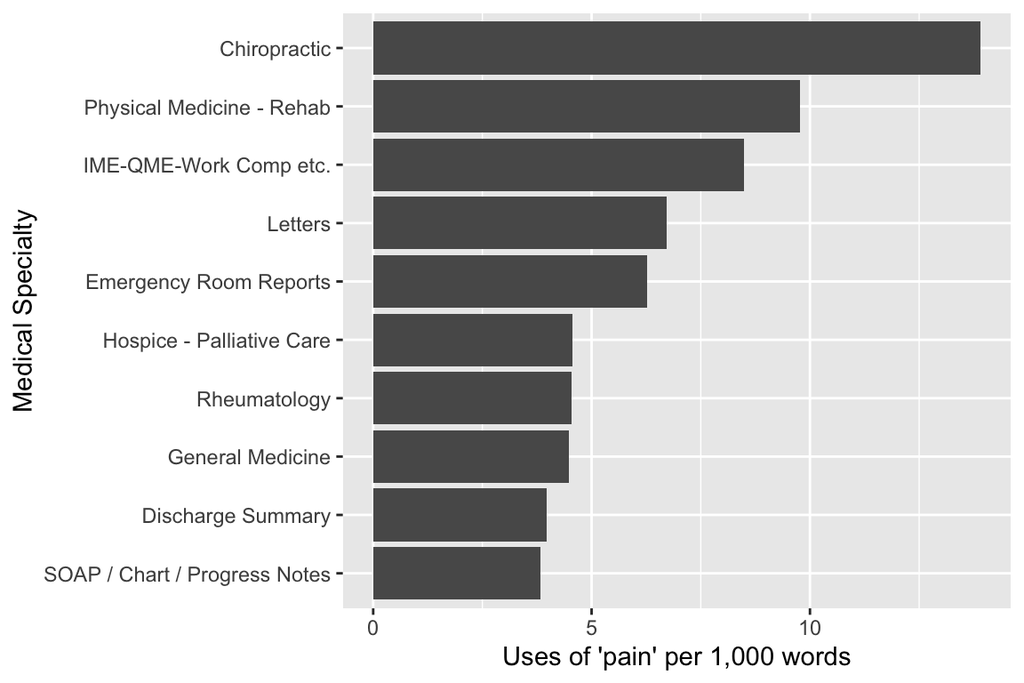

```r
pain_by_specialty |>
  top_n(10, pain_per_1000) |>
  ggplot(aes(
    pain_per_1000,
    fct_reorder(medical_specialty, pain_per_1000)
  )) +
  geom_col() +
  labs(
    x = "Uses of 'pain' per 1,000 words",
    y = "Medical Specialty"
  )
```